# New Dawn - Seasonal Overview

2024-05-05

[figure not shown]

#### Introduction

Welcome to the **New Dawn** alliance overview!

This overview contains information on the entire alliance after every Star Expedition season. If for some reason you have any suggestions, comments or ideas, feel free to contact Danny:

- Ingame: 104378119025
- Discord: _.danny._.

After every Star Expedition season, every guild takes note of the following stats of each player:

- Name
- CCL - *(Friends list lineup)*
- Star Expedition points
- Number of A-tiers

These statistics are then used to display relevant information on the growth on all different levels.

# Alliance

This section is devoted to displaying information on the entire Alliance level.

- Currently, we have **3** different guilds in our alliance!
- We have members in **36** different servers!

An overview of the management of the guilds is given below:

| Guild | Leader | Officials |
| --- | --- | --- |
| Eternity | Kyoki | Swed, TheL4cky |
| Entropy | {ØB} N£G | Zacny, LegendHood |
| Void | Specy | Jaykeh, Cyngxq, Groocifier |

### Power

The total CCL power of all players combined this season is **32 532 930 301!**

The guilds are compared side-by-side in the figure below.

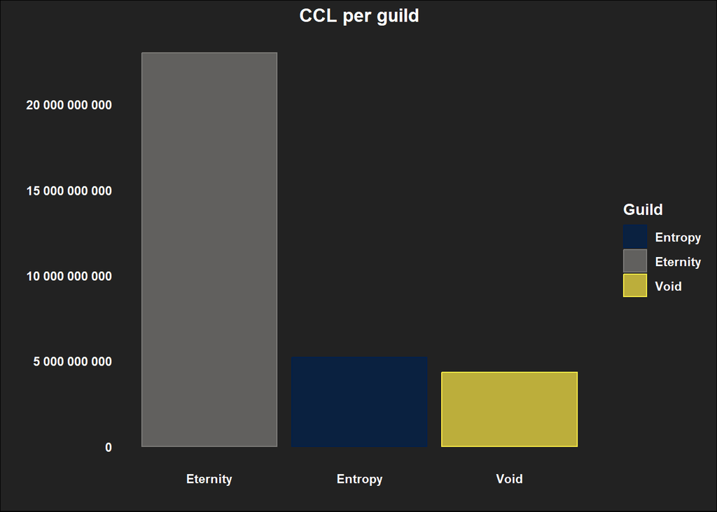

Next, we show a density plot covering the spread of the power per guild. The graph can be interpreted as follows:

- The **higher** the graph goes, the **more players** are situated around that power level.
- The more to the **right** the graph goes, the higher the power level, hence the **stronger** the player.

Having lots of strong players will result in a high graph far to the right and vice versa.

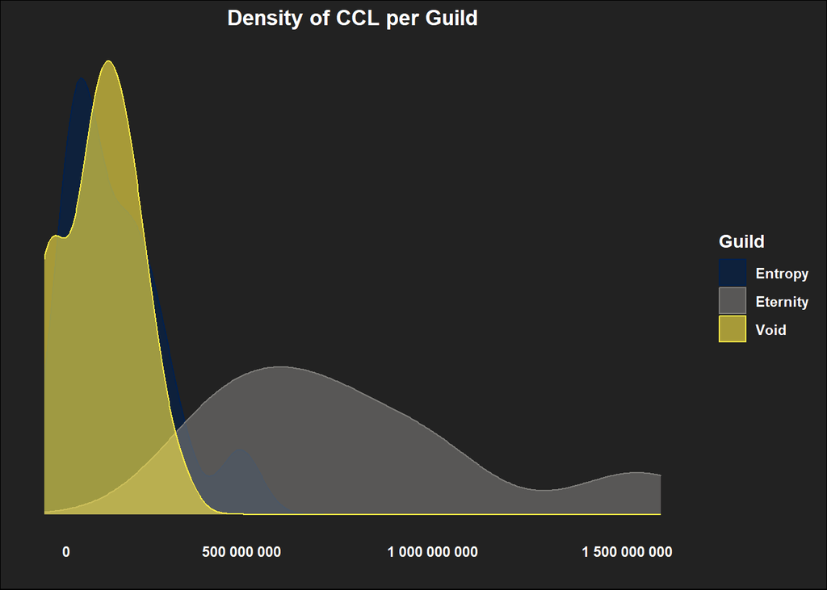

### Alliance MVP

Every Season, an alliance MVP is chosen. This is a player in our alliance who deserves to be put in the spotlights for a season.

*Coming soon.*

# Eternity

[figure not shown]

##### Guild Leader:

| ID | Name | Server |
| --- | --- | --- |
| 3551932578 | Kyoki | 35 |

### New Players

Coming next season!

### Power

- The total power in Eternity throughout this season was **23 012 000 000!**
- The average power per player is **793 517 241!**

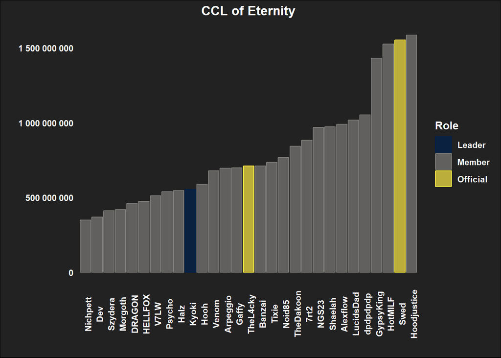

The way the power is spread out is shown in the graph below. The higher the graph is, the more players are around that power level.

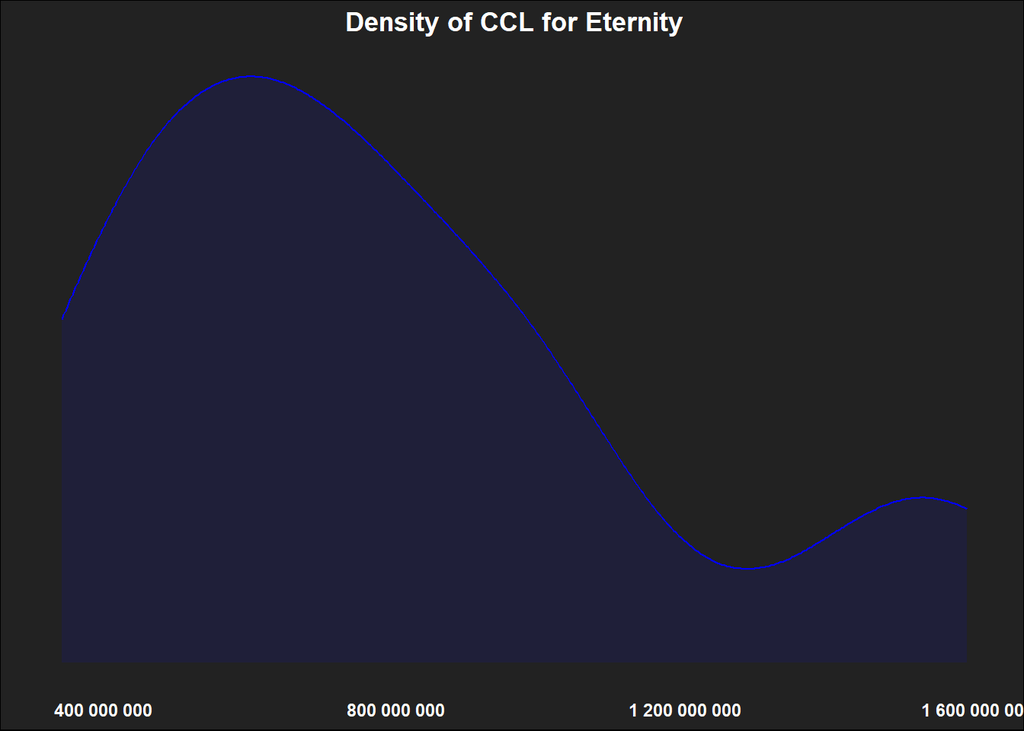

### Star Expedition

- The total SE score this season was **17 783 801 000 000.**
- The average score per player is **613 234 517 241.**

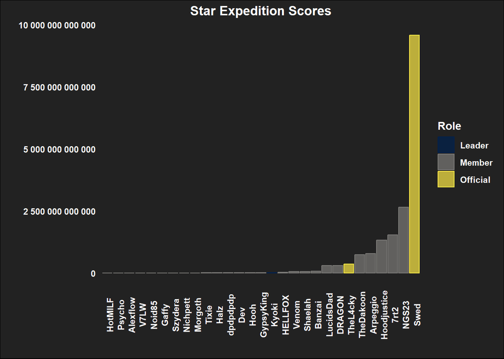

### Guild MVP

Coming next season!

# Entropy

[figure not shown]

##### Guild Leader:

| ID | Name | Server |
| --- | --- | --- |
| 268425659 | {ØB} N£G | 2 |

### New Players

Coming next season!

### Power

- The total power in Entropy throughout this season was **5 207 784 986!**
- The average power per player is **185 992 321!**

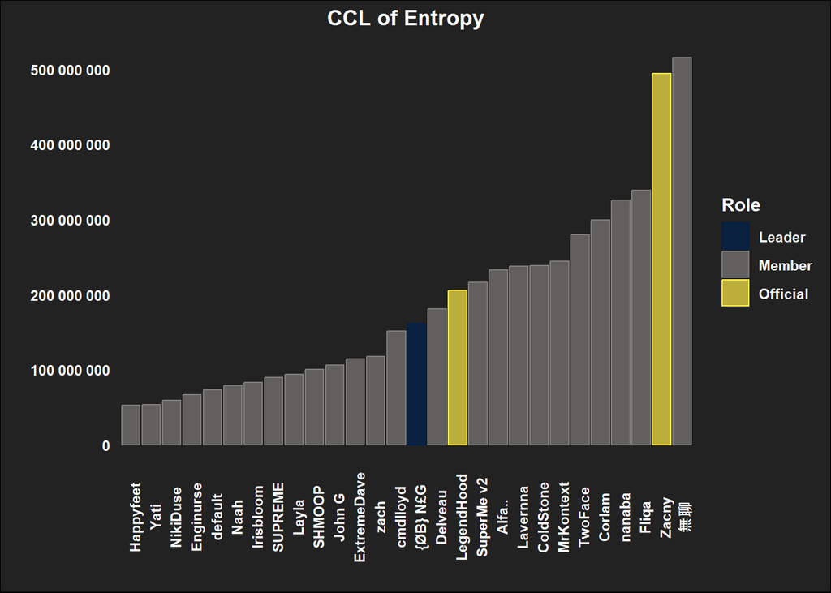

The way the power is spread out is shown in the graph below. The higher the graph is, the more players are around that power level.

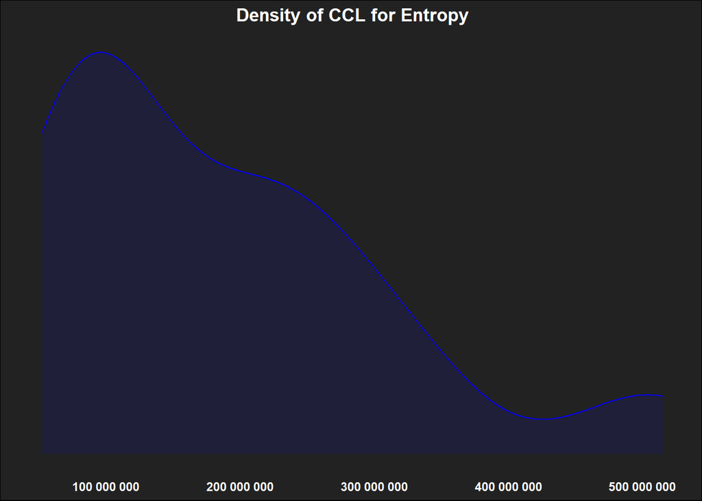

### Star Expedition

- The total SE score this season was **2 891 259 551.**
- The average score per player is **103 259 270.**

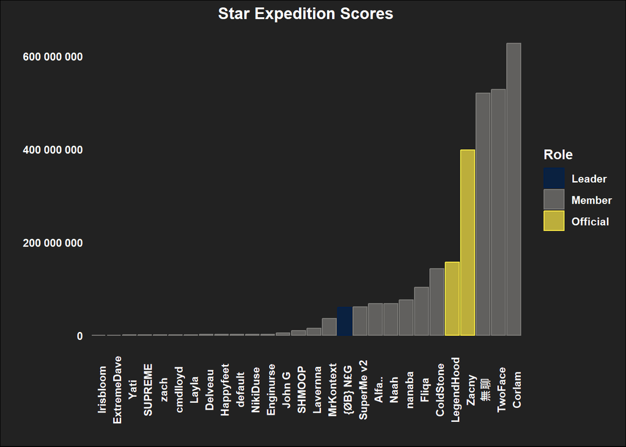

### Guild MVP

Coming next season!

# Void

[figure not shown]

##### Guild Leader:

| ID | Name | Server |
| --- | --- | --- |
| 107640180775 | Specy | 1076 |

### New Players

Coming next season!

### Power

- The total power in Void throughout this season was **4 313 145 315!**
- The average power per player is **143 771 511!**

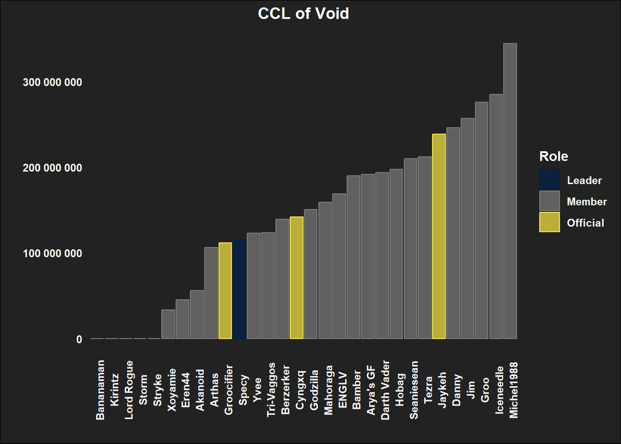

The way the power is spread out is shown in the graph below. The higher the graph is, the more players are around that power level.

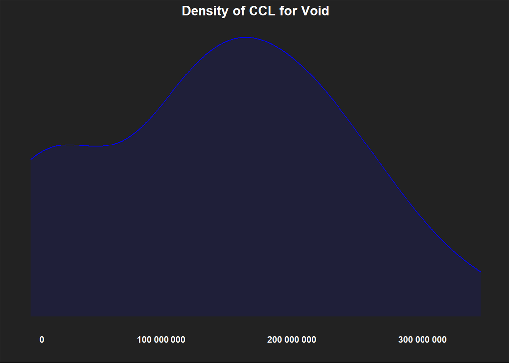

### Star Expedition

- The total SE score this season was **7 287 624 448.**
- The average score per player is **242 920 815.**

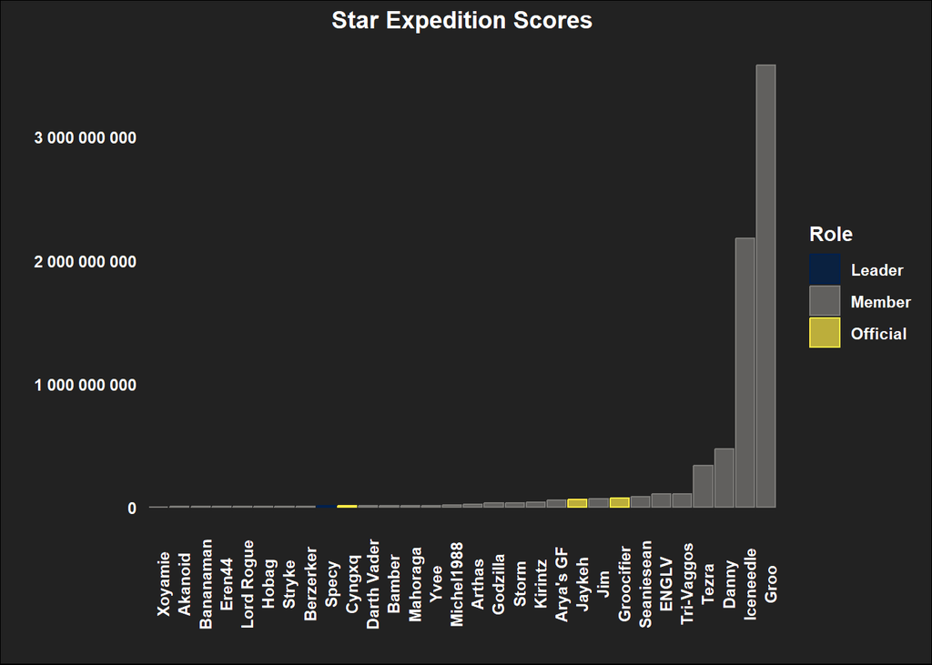

### Guild MVP

Coming next season!

# Ethereal

[figure not shown]

Stats coming next season!